# DV_RProject3

*Members* Raymundo Cortez Yuyin Wang Chigozi Yejekwe

### R_ETL

```r
require(tidyr)
require(dplyr)
require(ggplot2)
setwd("~/DataVisualization/DV_RProject3/01 Data")
file_path <- "Salary_Information_for_Industrial_Development_Agencies.csv"

df <- read.csv(file_path, stringsAsFactors = FALSE)
# Replace "." (i.e., period) with "_" in the column names.
names(df) <- gsub("\\.+", "_", names(df))
#shorten names longer than 30, or reserved words in SQL
df <- rename(df,Paid_by_State_or_Local_Gov=Paid_by_State_or_Local_Government)
df <- rename(df,Grp = Group)

measures <- c("Base_Annualized_Salary","Actual_Salary_Paid","Overtime_Paid","Performance_Bonus","Extra_Pay","Other_Compensation","Total_Compensation")

# Get rid of special characters in each column.
for(n in names(df)) {
  df[n] <- data.frame(lapply(df[n], gsub, pattern="[^ -~]",replacement= ""))
}

dimensions <- setdiff(names(df), measures)
if( length(measures) > 1 || ! is.na(dimensions)) {
  for(d in dimensions) {
    # Get rid of " and ' in dimensions.
    df[d] <- data.frame(lapply(df[d], gsub, pattern="[\"']",replacement= ""))
    # Change & to and in dimensions.
    df[d] <- data.frame(lapply(df[d], gsub, pattern="&",replacement= " and "))
    # Change : to ; in dimensions.
    df[d] <- data.frame(lapply(df[d], gsub, pattern=":",replacement= ";"))
  }
}


# Get rid of all characters in measures except for numbers, the - sign, and period.dimensions
if( length(measures) > 1 || ! is.na(measures)) {
  for(m in measures) {
    df[m] <- data.frame(lapply(df[m], gsub, pattern="[^--.0-9]",replacement= ""))
  }
}

write.csv(df, paste(gsub(".csv", "", file_path), ".reformatted.csv", sep=""), row.names=FALSE, na = "")

tableName <- gsub(" +", "_", gsub("[^A-z, 0-9, ]", "", gsub(".csv", "", file_path)))
sql <- paste("CREATE TABLE", tableName, "(\n-- Change table_name to the table name you want.\n")
if( length(measures) > 1 || ! is.na(dimensions)) {
  for(d in dimensions) {
    sql <- paste(sql, paste(d, "varchar2(4000),\n"))
  }
}
if( length(measures) > 1 || ! is.na(measures)) {
  for(m in measures) {
    if(m != tail(measures, n=1)) sql <- paste(sql, paste(m, "number(38,4),\n"))
    else sql <- paste(sql, paste(m, "number(38,4)\n"))
  }
}
sql <- paste(sql, ");")
cat(sql)

#repeat for second csv
file_path <- "Actual_avg_loc_salary.csv"

df <- read.csv(file_path, stringsAsFactors = FALSE)

# Replace "." (i.e., period) with "_" in the column names.
names(df) <- gsub("\\.+", "_", names(df))

df <- rename(df,Grp = Group)

measures <- c("AVG_LOC_BASE_ANU_SALARY","AVG_LOC_ACT_SALARY","AVG_LOC_OVERTIME","AVG_LOC_BONUS","AVG_LOC_EXTRA_PAY","AVG_LOC_TOT_COMP","AVG_LOC_OTHER_COMP")

# Get rid of special characters in each column.
for(n in names(df)) {
  df[n] <- data.frame(lapply(df[n], gsub, pattern="[^ -~]",replacement= ""))
}

dimensions <- setdiff(names(df), measures)
if( length(measures) > 1 || ! is.na(dimensions)) {
  for(d in dimensions) {
    # Get rid of " and ' in dimensions.
    df[d] <- data.frame(lapply(df[d], gsub, pattern="[\"']",replacement= ""))
    # Change & to and in dimensions.
    df[d] <- data.frame(lapply(df[d], gsub, pattern="&",replacement= " and "))
    # Change : to ; in dimensions.
    df[d] <- data.frame(lapply(df[d], gsub, pattern=":",replacement= ";"))
  }
}


# Get rid of all characters in measures except for numbers, the - sign, and period.dimensions
if( length(measures) > 1 || ! is.na(measures)) {
  for(m in measures) {
    df[m] <- data.frame(lapply(df[m], gsub, pattern="[^--.0-9]",replacement= ""))
  }
}

write.csv(df, paste(gsub(".csv", "", file_path), ".reformatted.csv", sep=""), row.names=FALSE, na = "")

tableName <- gsub(" +", "_", gsub("[^A-z, 0-9, ]", "", gsub(".csv", "", file_path)))
sql <- paste("CREATE TABLE", tableName, "(\n-- Change table_name to the table name you want.\n")
if( length(measures) > 1 || ! is.na(dimensions)) {
  for(d in dimensions) {
    sql <- paste(sql, paste(d, "varchar2(4000),\n"))
  }
}
if( length(measures) > 1 || ! is.na(measures)) {
  for(m in measures) {
    if(m != tail(measures, n=1)) sql <- paste(sql, paste(m, "number(38,4),\n"))
    else sql <- paste(sql, paste(m, "number(38,4)\n"))
  }
}
sql <- paste(sql, ");")
cat(sql)
```

### Summary

The first of our datasets is the “Salary Information for Industrial Development Agencies”. The Dataset includes information on employees for Industrial Development Agencies in the State of New York. The information includes for each employee, Title, Group (Executive, Managerial, etc…), Department, Pay Type, Exempt Indicator, Paid by state or local government, paid by another entity, base annualized salary, actual salary paid, overtime paid, performance bonus, extra pay, other compensation and total compensation. The second dataset is taken from the “Salary Information for Local Development Corporations”. The Dataset included information on employees for Local Development Corporations in the State of New York. The averages of their base annualized salary, actual salary paid, overtime paid, performance bonus extra pay, other compensation and total compensation based on Group were then compiled into a Dataset named “Actual Average Local Salary”.

### Workflows and graphs

```
##
## > require("dplyr")
##
## > require("ggplot2")
##
## > require("jsonlite")
##
## > require("RCurl")
##
## > idf <- data.frame(fromJSON(getURL(URLencode("129.152.144.84:5001/rest/native/?query=\"select * from SINFOINDUSTRIALA\""),
## +     httpheader = c(DB = .... [TRUNCATED]
##
## > aldf <- data.frame(fromJSON(getURL(URLencode("129.152.144.84:5001/rest/native/?query=\"select * from AVG_LOC_SALARY\""),
## +     httpheader = c(DB =  .... [TRUNCATED]
##
## > idf$TOTAL_COMPENSATION <- as.numeric(as.character(idf$TOTAL_COMPENSATION))
##
## > aldf$AVG_LOC_OTHER_COMP <- as.numeric(as.character(aldf$AVG_LOC_OTHER_COMP))
##
## > dplyr::left_join(idf, aldf, by = "GRP") %>% select(GRP,
## +     TOTAL_COMPENSATION, AVG_LOC_OTHER_COMP) %>% mutate(DIFFAVG = TOTAL_COMPENSATION -
## +  .... [TRUNCATED]
```

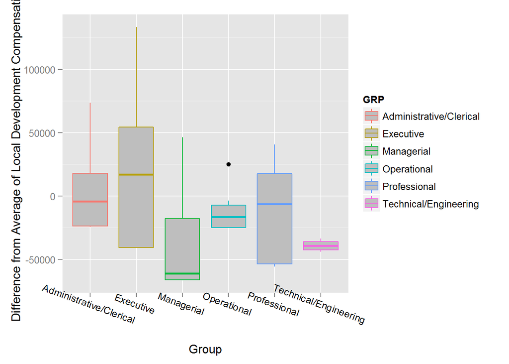

```r
idf <- data.frame(fromJSON(getURL(URLencode('129.152.144.84:5001/rest/native/?query="select * from SINFOINDUSTRIALA"'),httpheader=c(DB='jdbc:oracle:thin:@129.152.144.84:1521/PDBF15DV.usuniversi01134.oraclecloud.internal', USER='cs329e_rc37495', PASS='orcl_rc37495', MODE='native_mode', MODEL='model', returnDimensions = 'False', returnFor = 'JSON'), verbose = TRUE), ))

aldf <- data.frame(fromJSON(getURL(URLencode('129.152.144.84:5001/rest/native/?query="select * from AVG_LOC_SALARY"'),httpheader=c(DB='jdbc:oracle:thin:@129.152.144.84:1521/PDBF15DV.usuniversi01134.oraclecloud.internal', USER='cs329e_rc37495', PASS='orcl_rc37495', MODE='native_mode', MODEL='model', returnDimensions = 'False', returnFor = 'JSON'), verbose = TRUE), ))


idf$TOTAL_COMPENSATION <- as.numeric(as.character(idf$TOTAL_COMPENSATION))
aldf$AVG_LOC_OTHER_COMP <- as.numeric(as.character(aldf$AVG_LOC_OTHER_COMP))

dplyr::left_join(idf,aldf,by="GRP") %>% select(GRP,TOTAL_COMPENSATION,AVG_LOC_OTHER_COMP) %>% mutate(DIFFAVG = TOTAL_COMPENSATION - AVG_LOC_OTHER_COMP) %>% filter(GRP == c("Executive","Managerial","Administrative/Clerical","Professional","Operational","Technical/Engineering")) %>% ggplot(aes(x = GRP, y = DIFFAVG, colour = GRP)) + geom_boxplot(fill = "grey") + labs(x="Group",y="Difference from Average of Local Development Compensation") + theme(axis.text.x=element_text(angle=-20,color="black"))
```

*Graph 2* Average Overtime Comparison of NY Development Agencies

It appears that local companies (commercially created) log a lot of overtime, especially Operational or Administrative/Clerical type jobs. Executive and Techincal/Engineering type jobs appears to have essentially no overtime in both industrial agencies (government created) and local companies. Overall, local company employees record a siginificantly more amount of overtime than their industrial agency counterparts.

```
##
## > require("dplyr")
##
## > require("ggplot2")
##
## > require("jsonlite")
##
## > require("RCurl")
##
## > industry <- data.frame(fromJSON(getURL(URLencode("129.152.144.84:5001/rest/native/?query=\"select * from SINFOINDUSTRIALA\""),
## +     httpheader = c .... [TRUNCATED]
##
## > local <- data.frame(fromJSON(getURL(URLencode("129.152.144.84:5001/rest/native/?query=\"select * from AVG_LOC_SALARY\""),
## +     httpheader = c(DB = .... [TRUNCATED]
##
## > local <- local[1:6, ]
##
## > industry$OVERTIME_PAID <- as.numeric(as.character(industry$OVERTIME_PAID))
##
## > local$AVG_LOC_OVERTIME <- as.numeric(as.character(local$AVG_LOC_OVERTIME))
##
## > industry_summary <- aggregate(OVERTIME_PAID ~ GRP,
## +     industry, mean)
##
## > local <- local %>% arrange(desc(AVG_LOC_OVERTIME))
##
## > combined <- dplyr::inner_join(local, industry_summary,
## +     by = "GRP")
##
## > ggplot(data = combined, aes(x = GRP, y = AVG_LOC_OVERTIME,
## +     group = 1)) + geom_line(colour = "blue", size = 2) + geom_point(colour = "blue",
##  .... [TRUNCATED]
```

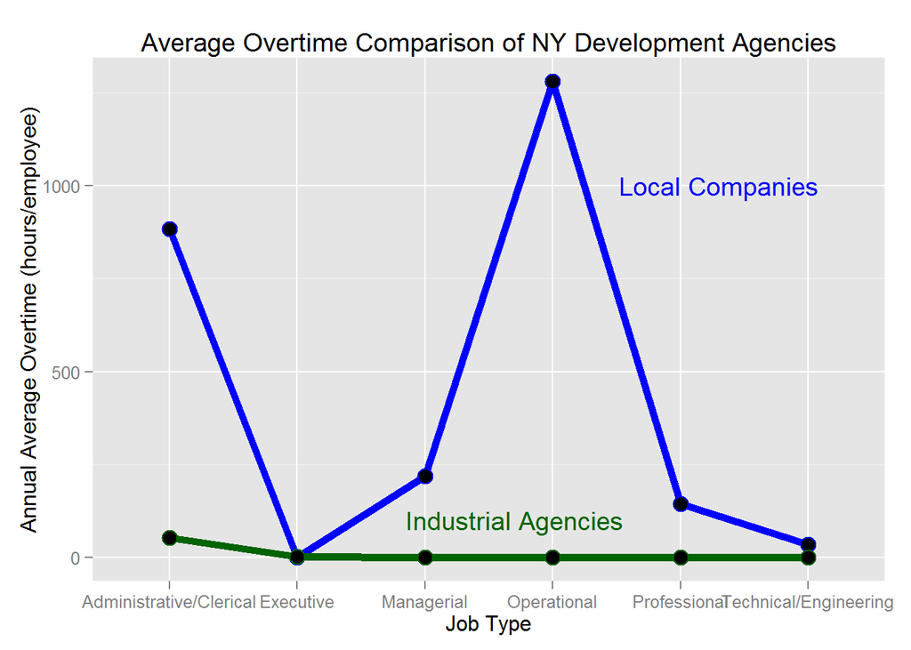

```r
# get required packages
require("dplyr")
require("ggplot2")
require("jsonlite")
require("RCurl")

# read files
industry <- data.frame(fromJSON(getURL(URLencode('129.152.144.84:5001/rest/native/?query="select * from SINFOINDUSTRIALA"'),httpheader=c(DB='jdbc:oracle:thin:@129.152.144.84:1521/PDBF15DV.usuniversi01134.oraclecloud.internal', USER='cs329e_rc37495', PASS='orcl_rc37495', MODE='native_mode', MODEL='model', returnDimensions = 'False', returnFor = 'JSON'), verbose = TRUE), ))
local <- data.frame(fromJSON(getURL(URLencode('129.152.144.84:5001/rest/native/?query="select * from AVG_LOC_SALARY"'),httpheader=c(DB='jdbc:oracle:thin:@129.152.144.84:1521/PDBF15DV.usuniversi01134.oraclecloud.internal', USER='cs329e_rc37495', PASS='orcl_rc37495', MODE='native_mode', MODEL='model', returnDimensions = 'False', returnFor = 'JSON'), verbose = TRUE), ))

# prepare to join tables
local <- local[1:6,]
industry$OVERTIME_PAID <- as.numeric(as.character(industry$OVERTIME_PAID))
local$AVG_LOC_OVERTIME <- as.numeric(as.character(local$AVG_LOC_OVERTIME))
industry_summary <- aggregate(OVERTIME_PAID ~ GRP, industry, mean)
local <- local %>% arrange(desc(AVG_LOC_OVERTIME))

# join tables
combined <- dplyr::inner_join(local, industry_summary, by = "GRP")

# make graph
ggplot(data=combined, aes(x=GRP, y=AVG_LOC_OVERTIME, group=1)) +
  geom_line(colour="blue", size=2) +
  geom_point(colour="blue", size=4, shape=21, fill="black") +
  geom_line(data=combined, aes(x=GRP, y=OVERTIME_PAID, group=1), colour="dark green", size=2) +
  geom_point(data=combined, aes(x=GRP, y=OVERTIME_PAID, group=1), colour="dark green", size=4, shape=21, fill="black") +
  labs(title = "Average Overtime Comparison of NY Development Agencies", x = "Job Type", y = "Annual Average Overtime (hours/employee)") +
  annotate("text", x=5.3, y=1000, colour="blue", label = "Local Companies") +
  annotate("text", x = 3.7, y = 100, colour="dark green", label = "Industrial Agencies")
```

*Graph 3* Comparing Salary Paid by Group and Name, to test the idea of income equality between genders.

```
##
## > require("jsonlite")
##
## > require("RCurl")
##
## > idf <- data.frame(fromJSON(getURL(URLencode("129.152.144.84:5001/rest/native/?query=\"select * from SINFOINDUSTRIALA\""),
## +     httpheader = c(DB = .... [TRUNCATED]
##
## > aldf <- data.frame(fromJSON(getURL(URLencode("129.152.144.84:5001/rest/native/?query=\"select * from AVG_LOC_SALARY\""),
## +     httpheader = c(DB =  .... [TRUNCATED]
##
## > new_df <- dplyr::right_join(idf, aldf, by = "GRP")
##
## > new_df_two <- new_df %>% select(GRP, FIRST_NAME, ACTUAL_SALARY_PAID) %>%
## +     sample_n(600) %>% filter(ACTUAL_SALARY_PAID != 0) %>% group_by(GRP)
##
## > new_df_two <- new_df %>% select(GRP, FIRST_NAME, ACTUAL_SALARY_PAID) %>%
## +     sample_n(600) %>% filter(ACTUAL_SALARY_PAID != 0) %>% group_by(GRP)
##
## > head(new_df_two)
## Source: local data frame [6 x 3]
## Groups: GRP
##
##                       GRP FIRST_NAME ACTUAL_SALARY_PAID
## 1 Administrative/Clerical      Wanda              43316
## 2               Executive      Jaime      77160.2265625
## 3            Professional   Nicholas              15000
## 4 Administrative/Clerical     Carrie              37896
## 5               Executive      Tracy              78808
## 6               Executive    Stephen              85000
##
## > new_df_two %>% sample_n(1) %>% ggplot(aes(x = FIRST_NAME,
## +     y = ACTUAL_SALARY_PAID, fill = GRP)) + geom_bar(stat = "identity") +
## +     theme(p .... [TRUNCATED]
```

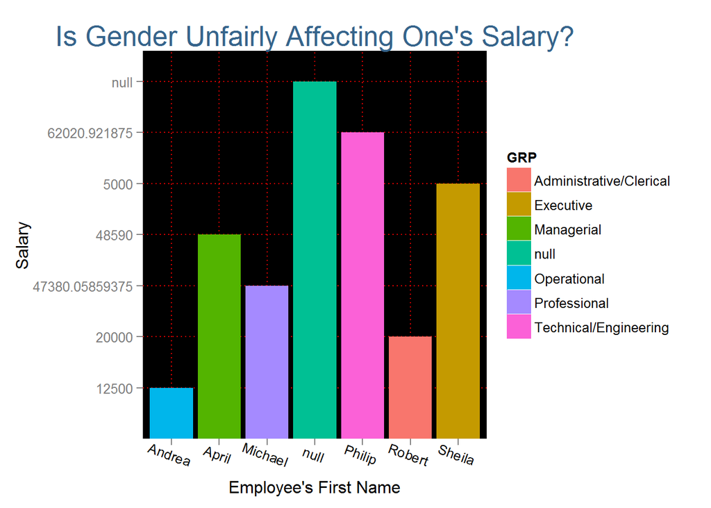

```r
require("jsonlite")
require("RCurl")
idf <- data.frame(fromJSON(getURL(URLencode('129.152.144.84:5001/rest/native/?query="select * from SINFOINDUSTRIALA"'),httpheader=c(DB='jdbc:oracle:thin:@129.152.144.84:1521/PDBF15DV.usuniversi01134.oraclecloud.internal', USER='cs329e_rc37495', PASS='orcl_rc37495', MODE='native_mode', MODEL='model', returnDimensions = 'False', returnFor = 'JSON'), verbose = TRUE), ))

aldf <- data.frame(fromJSON(getURL(URLencode('129.152.144.84:5001/rest/native/?query="select * from AVG_LOC_SALARY"'),httpheader=c(DB='jdbc:oracle:thin:@129.152.144.84:1521/PDBF15DV.usuniversi01134.oraclecloud.internal', USER='cs329e_rc37495', PASS='orcl_rc37495', MODE='native_mode', MODEL='model', returnDimensions = 'False', returnFor = 'JSON'), verbose = TRUE), ))

new_df <- dplyr::right_join(idf,aldf,by="GRP")
##joining the 2 datasets using right_join method. Right join joins datasets by matching rows from a to b

##For the combined data set, We wanted to test income equality between genders.

##first edited dataset by selecting for group, first name, and the actual salary that the employee was paid.
#new_df %>% select(GRP, FIRST_NAME, ACTUAL_SALARY_PAID)

##Next, we sampled 600 rows of the data using the sample_n() formula to pull out different people.
 new_df_two <- new_df %>% select(GRP, FIRST_NAME, ACTUAL_SALARY_PAID) %>% sample_n(600) %>% filter(ACTUAL_SALARY_PAID != 0) %>% group_by(GRP)

##In addition, because we noticed that some employees had a Paid salary of 0, we further editted the code to removed those people using filter().
new_df_two <- new_df %>% select(GRP, FIRST_NAME, ACTUAL_SALARY_PAID) %>% sample_n(600) %>% filter(ACTUAL_SALARY_PAID != 0) %>% group_by(GRP)

##head of new data frame
head(new_df_two)

##Created a graph to represent the data. Obviously since we can't see these people, we can't tell for sure their gender; however, we can infer their gender based on their name. For instance, someone named "Peter" is highly likely to be male or a "Sarah" will more than likely be female.
##The idea is to check the names and see what they were paid and compare. If we see that feminine-sounding names were, on average, receiving less compensation than male-sounding names then we can INFER that there was some form of income inequality being exhibited.

new_df_two %>% sample_n(1) %>% ggplot(aes(x = FIRST_NAME, y = ACTUAL_SALARY_PAID, fill = GRP)) + geom_bar(stat = "identity") + theme(panel.background = element_rect(fill = "black")) + theme(panel.grid.major = element_line(color = "red", linetype = "dotted")) + theme(plot.background = element_rect(fill = "white")) + ggtitle("Is Gender Unfairly Affecting One's Salary?") + theme(plot.title = element_text(color = "steelblue4", size = 20)) + xlab("Employee's First Name") + ylab("Salary") + theme(axis.text.x=element_text(angle=-20,color="black"))

##Colored the graph by group so that not only can we compare by the person's first name then we can also compare within the groups and see if individual's with feminine names were getting paid less than their male counterparts in the same position. For aesthetic reasons, I altered the graph in order to change the x-axis title, y-axis title, graph title, and then added more color to the graph in the background and with the titles.

##Final notes: Because of how the data was joined, it proved difficult to remove all null values hence why "null" is on the graph in both the x and y axis. For analytical purposes, these null-named individuals should be thrown out.
##Because the data is sampled each time, a new dataset is created. However, the advantage is that you can continuously create trials and keep comparing until a more accurate picture is created.
```